# STA457 Assignment (Fall 2020)

Harold Hyun Woo Lee & 1003410908

2020-12-03

1. Download delinquency rates and real GDP data from Quercus and put them into your working directory.
2. Calculate the changes of real GDP using the following R codes.

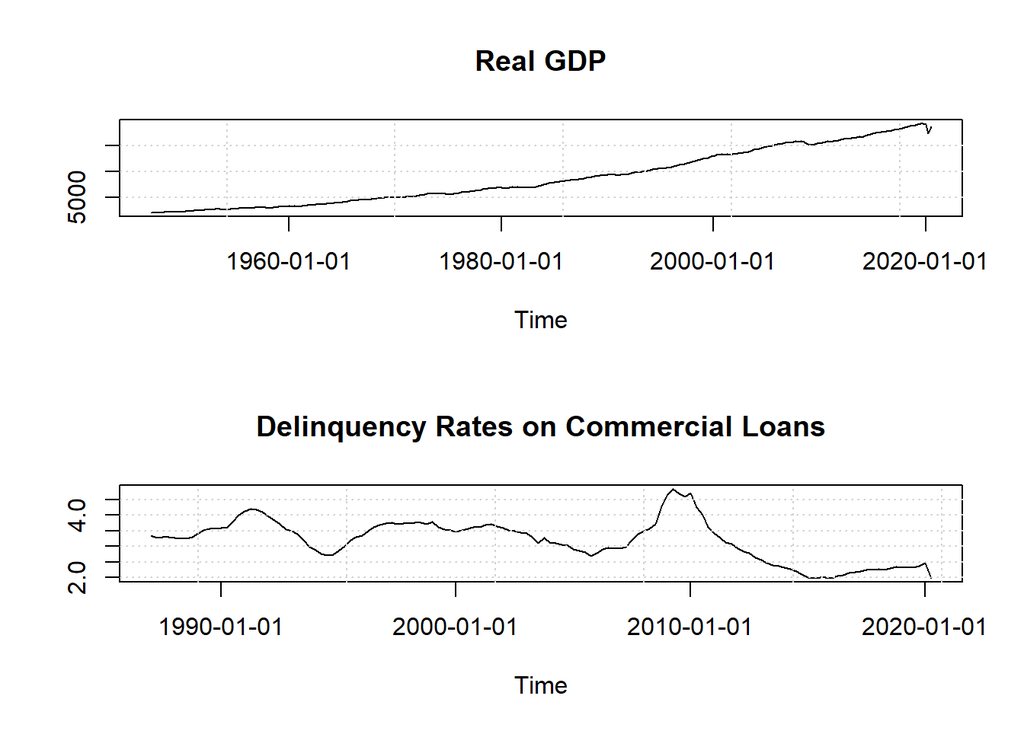

```r
###1.
dat <- read.csv("GDPC1.csv")
CL <- read.csv("DRCLACBS.csv")


gdp_tim<-timeSequence(from = "1947-01-01", to = "2020-07-01", by = "quarter")
gdp<- timeSeries(dat$GDPC1, charvec = gdp_tim)

CL_tim <-timeSequence(from = "1987-01-01", to = "2020-04-01", by = "quarter")
CL<- timeSeries(CL$DRCLACBS, charvec = CL_tim)

par(mfrow=c(2,1))
plot(gdp, pch = 18, main = "Real GDP", xlab="Time", ylab="");grid()
plot(CL, pch = 18, main = "Delinquency Rates on Commercial Loans", xlab="Time", ylab="");
grid()
```

```r
###2.
RGDP = ts(diff(dat[,2])/100,frequency = 4, end = c(2020,3))
```

### Use the data from 1987 Q1 to 2018 Q2

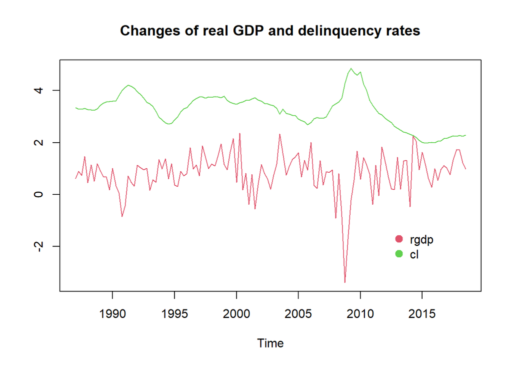

##### Model this relationship using the transfer function noise model.(For simplicity, assume that both delinquency rates and changes of real GDP are stationary.)

Your analyses should include:

1. Conduct `prewhitening` analysis to identify the lead-lag relationship between changes of real GDP and delinquency rates;
   - ARMA model for changes of real GDP and its residual ACF and PACF plots
   - Use cross correlation plot of prewhitened processes to identify transfer function ($\nu_i$)

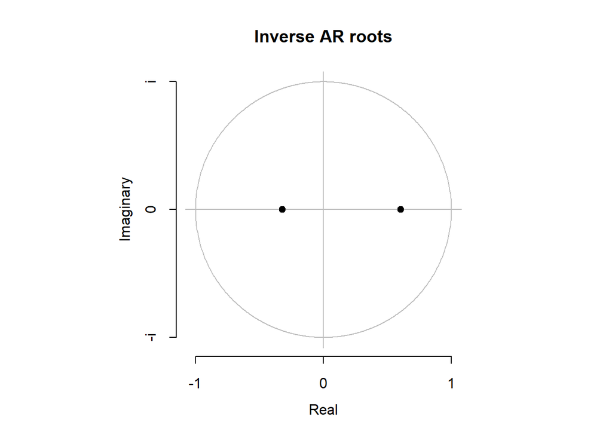

```r
#Fit an ARMA model first to determine p, q then conduct prewhitening
# Select an ARMA(p,q) model using AIC
RGDP.arma <- auto.arima(RGDP_train, max.p = 52, max.q = 52, stationary = TRUE)
nAR = RGDP.arma$arma[1]; nMA = RGDP.arma$arma[2]

# Algorithm fits an ARMA(2,0,0)

# Check that Inverse roots are within the unit circle
plot(RGDP.arma)
```

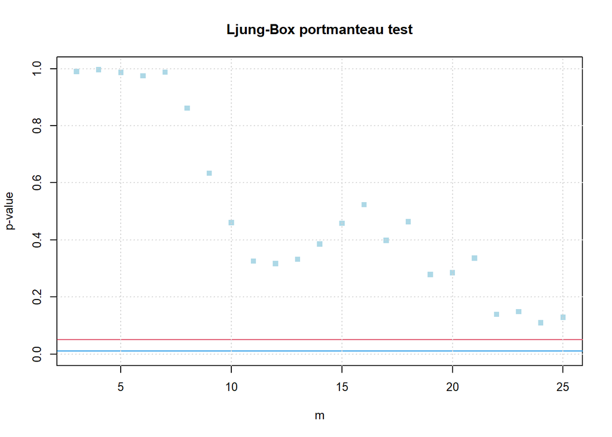

```r
# check model adequacy using the function provided by the Professor for the
# Ljung-Box test (LBTest)
par(mfrow = c(1,1), cex = 0.8)
LBTest(RGDP.arma$residuals, nPQ = nAR+nMA, m = 25, ifPlot = TRUE)
```

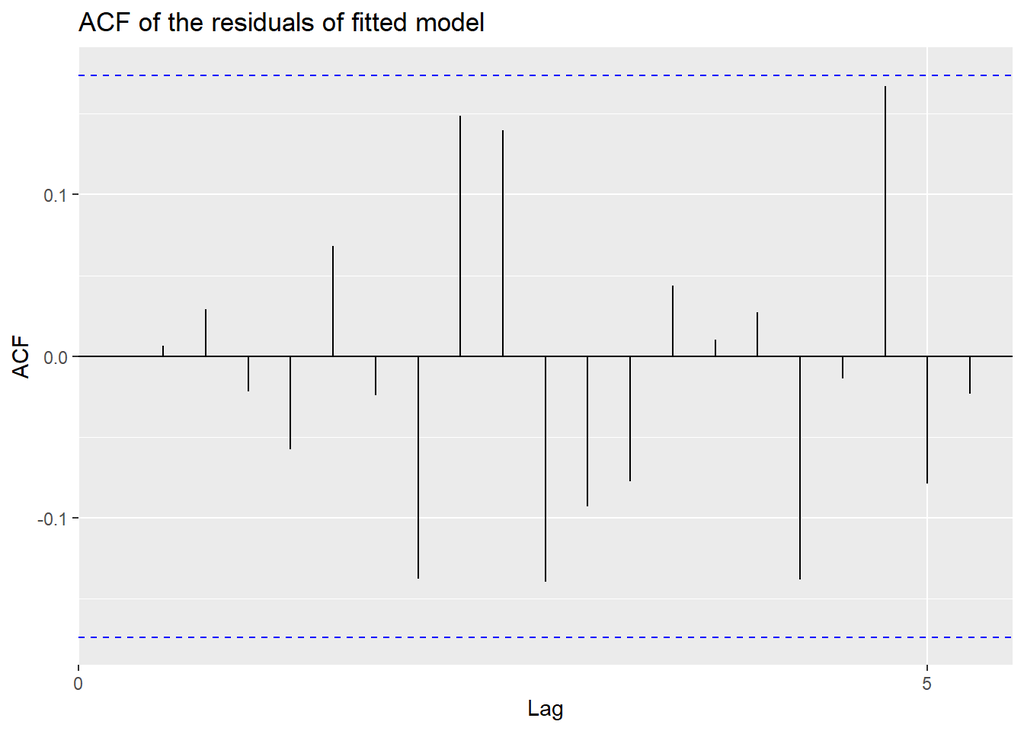

```r
# all are above the 5% significance level, so this appears adequate

# Check the model residual is approximately white noise.
autoplot(acf(RGDP.arma$residuals, plot=FALSE), main="ACF of the residuals of fitted model")
```

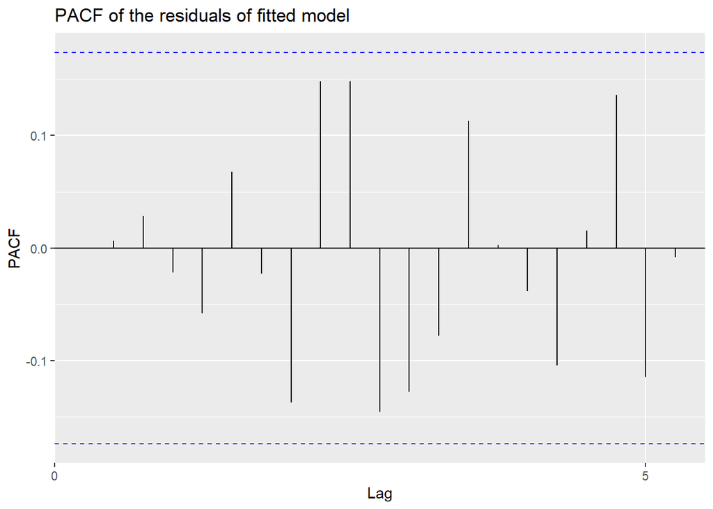

```r
autoplot(pacf(RGDP.arma$residuals, plot=FALSE), main = "PACF of the residuals of fitted model")
```

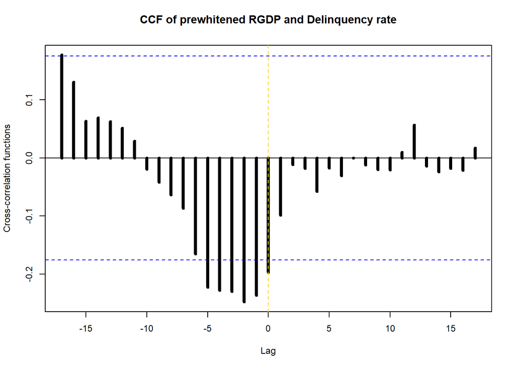

```r
# Residuals are approximately 0 and show no correlation -> white noise.


#' @prewhiten x, y
mod = RGDP.arma
if(nMA!=0){
  xf = PreWhiten.arma(RGDP_train, ar = mod$coef[1:nAR],
                      ma = mod$coef[(1:nMA)+nAR])[-(1:nAR)]
  yf = PreWhiten.arma(CL_train, ar = mod$coef[1:nAR],
                      ma=mod$coef[(1:nMA)+nAR])[-(1:nAR)]
}else{
  xf = PreWhiten.arma(RGDP_train, ar = mod$coef[1:nAR],
                      ma = 0)[-(1:nAR)]
  yf = PreWhiten.arma(CL_train, ar = mod$coef[1:nAR],
                      ma=0)[-(1:nAR)]
}


#' @ccf plot prewhiten x and y

par(cex=0.75)
ccf(c(xf), c(yf), lwd=4, ylab="Cross-correlation functions",
    main="CCF of prewhitened RGDP and Delinquency rate")
abline(v=0, col="gold", lwd=1, lty="dashed")
text(1, 0.2, "0", col=2)
text(-2, 0.2, "-1", col=3)
text(-3, 0.2, "-2", col=2)
text(-4, 0.2, "-3", col=2)
text(-5, 0.2, "-4", col=2)
text(-6, 0.2, "-5", col=2)
```

```r
# 0, -1, -2, -3, -4, -5 are identified using cross-correlation function
```

2. Fit a multiple regression using the findings in the `prewhitening` step, i.e.
   $$y_t = \sum_i v_i x_{t-i} +\xi_t,~~~(1)$$
   where $y_t$ and $x_t$ denote the output and input process, respectively, and $\xi_t$ is the noise process.(Hint: Use `prewhitening` to select the lagged $\{x_i\}$ in the regression)

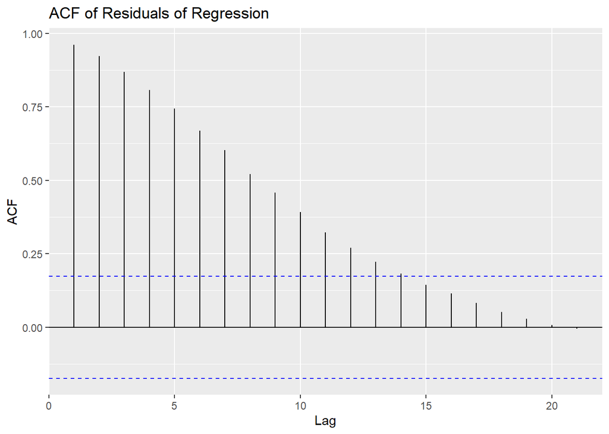

```r
#' @fit Equation (1)

# I am storing lag values as matrix to fit a lm model
lag_matrix <- matrix(c(RGDP, lag(RGDP),lag(RGDP, 2), lag(RGDP, 3), lag(RGDP, 4),
             lag(RGDP, 5)), ncol=6)
lag_matrix <- timeSeries(lag_matrix, charvec = RGDP_tim)
colnames(lag_matrix) <- c("lag0","lag1","lag2","lag3","lag4","lag5")

RGDP_lags <- window(lag_matrix, start="1987-01-01", end="2018-07-01")

# Fitting equation (1)
mod.reg <- lm(CL_train~(RGDP_lags[,1] + RGDP_lags[,2]+ RGDP_lags[,3] +
                          RGDP_lags[,4] + RGDP_lags[,5] + RGDP_lags[,6]))


#' @plot residual ACF and PACF of the above regression

autoplot(acf(mod.reg$residuals, plot = FALSE), main="ACF of Residuals of Regression")
```

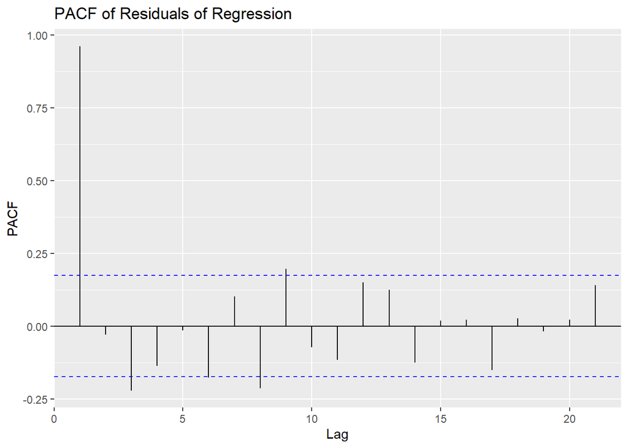

```r
autoplot(pacf(mod.reg$residuals, plot=FALSE), main="PACF of Residuals of Regression")
```

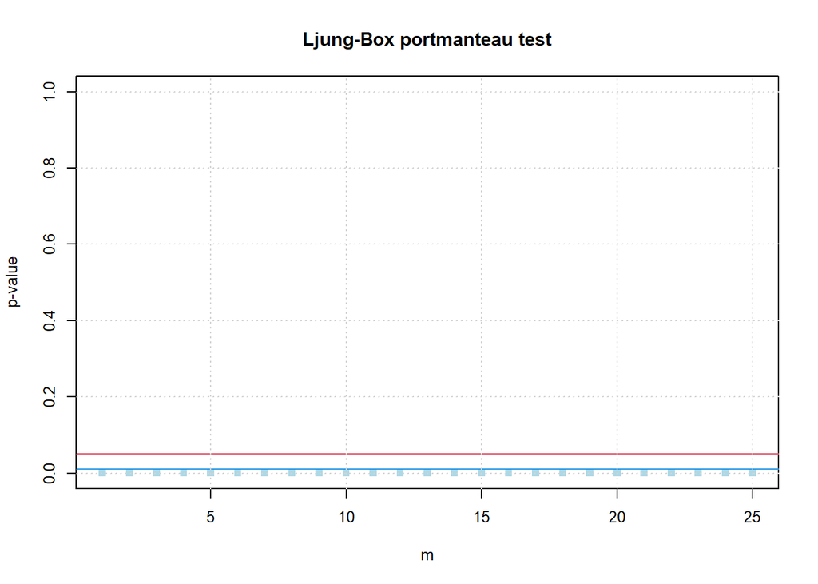

```r
# check model adequacy using the function provided by the Professor for the
# Ljung-Box test (LBTest)
par(mfrow = c(1,1), cex = 0.8)
LBTest(mod.reg$residuals, nPQ = 0, m = 25, ifPlot = TRUE)
```

Here we can see the result of the ACF and PACF graph of the residuals of regression model. Notice that ACF graph looks like a stair approaching 0 as lag value increases (especially around 20). The model does not pass Ljung-Box test as P-value is all approximately 0.

4. Fit a transfer function noise model using the rational distributed lag function, i.e.
   $$y_t = \frac{\delta(B)}{\omega(B)}x_t+n_t,~~~(2)$$
   where $\delta(B)$ and $\omega(B)$ are polynomials in the backward shift operator $B$, and $n_t$ follows an ARMA process. Write down the mathematical representation of the fitted model.

```r
#' @fit Equation (2) and show the fitted model
# Data is our data with first column as delinquency rate
# rest of the columns are lag values

data <- cbind(CL_train, RGDP_lags)

# My TFN model is Arima(4,0,2)
# There can be many solutions but this is one of many
mod.tfn <- auto.arima(data[,1], xreg=data[,-1], max.p = 4, start.p = 4, start.q = 2,
                      max.P = 0, max.Q=0, stationary = TRUE)
mod.tfn$coef
```

```
##         ar1         ar2         ar3         ar4         ma1         ma2
## -0.01961546  1.23993751  0.30686122 -0.61651101  1.42658817  0.56676368
##   intercept        lag0        lag1        lag2        lag3        lag4
##  3.40953237 -0.05653133 -0.04733939 -0.05519445 -0.03672817 -0.03650043
##        lag5
## -0.04366943
```

- **Write down the mathematical equation of your fitted model**

Mathematically we can express it as:

$$y_t = -0.02y_{t-1}+1.24y_{t-2}+0.31y_{t-3}-0.62y_{t-4}+3.41-0.06x_t-0.05x_{t-1}-0.06x_{t-2}-0.04x_{t-3}-0.04x_{t-4}-0.04x_{t-5} + \\ a_t + 1.43a_{t-1} + 0.57a_{t-2}$$

Written in compact notation we have:

$$(1+0.02B-1.24B^2-0.31B^3+0.62B^4)y_t = 3.41-(0.06+0.05B+0.06B^2+0.04B^3+0.04B^4+0.04B^5)x_t+ \\ (1+1.43B+0.57B^2)a_t$$

Simplified we get:

$$y_t = \frac{3.41}{(1+0.02B-1.24B^2-0.31B^3+0.62B^4)} - \frac{(0.06+0.05B+0.06B^2+0.04B^3+0.04B^4+0.04B^5)}{(1+0.02B-1.24B^2-0.31B^3+0.62B^4)}x_t + \\ \frac{(1+1.43B+0.57B^2)}{(1+0.02B-1.24B^2-0.31B^3+0.62B^4)}a_t$$

5. Conduct the model adequacy tests (diagnostics) on the above models and conclude your inference.

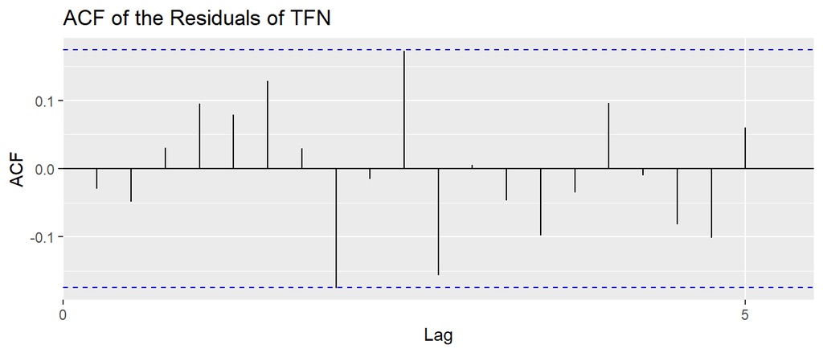

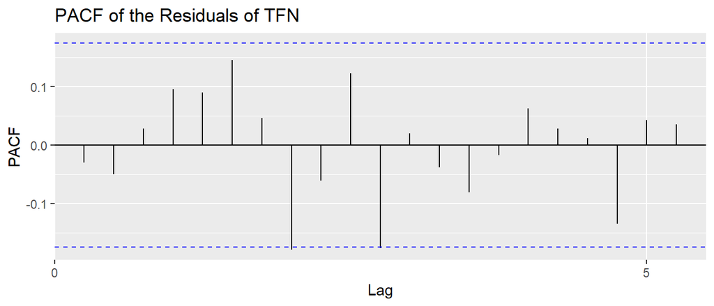

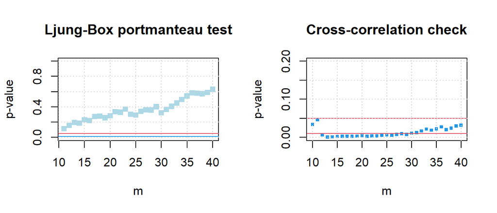

##### Conduct the out of sample forecasts of the above fitted models using the remaining observations. Calculate the forecast performance using Mean squared error (MSE), Mean absolute error (MAE), and Mean absolute percentage error (MAPE):

$$MSE = \sqrt \frac{\sum_{i=1}^L (y_{t+i}-\hat y_t(i))^2}{L}$$
$$MAE = \frac{\sum_{i=1}^L \left|y_{t+i}-\hat y_t(i)\right|}{L}$$
$$MAPE = \frac{1}{L}\sum_{i=1}^L \left|1-\frac{\hat y_t(i)}{y_{t+i}}\right|,$$
where $\hat y_t(i)$ denotes the forecast at origin $t$ with lead time $i$

```r
#' @forecast using tfn
# Call our delinquency forecast data as yobs
yobs <- CL_test
yhat_tfn <- forecast(mod.tfn, h = 6 , xreg = data[,-1], level=0.95)
# We only want the first 7 predictions
yhat_tfn <- round(c(as.numeric(yhat_tfn$mean)[1:7]), 2)



#' @calculate MSE, MAE, MAPE
MSE_tfn <- sqrt(mean((yobs - yhat_tfn)^2))

MAE_tfn <- mean(abs(yobs - yhat_tfn))

MAPE_tfn <- mean(abs(1-yhat_tfn/yobs))

MSE_tfn
```

```
## [1] 0.3350267
```

```r
MAE_tfn
```

```
## [1] 0.2757143
```

```r
MAPE_tfn
```

```
## [1] 0.1254393
```

##### 4. Conduct the same out of sample forecasts soley on $y_t$ using an ARIMA model. Compare and discuss its peformance metrics with the TFN model.

- **Hint:** You may fit an ARIMA model on $y_t$ using `auto.arima` but ensure that the fitted model pass the Ljung-Box test.

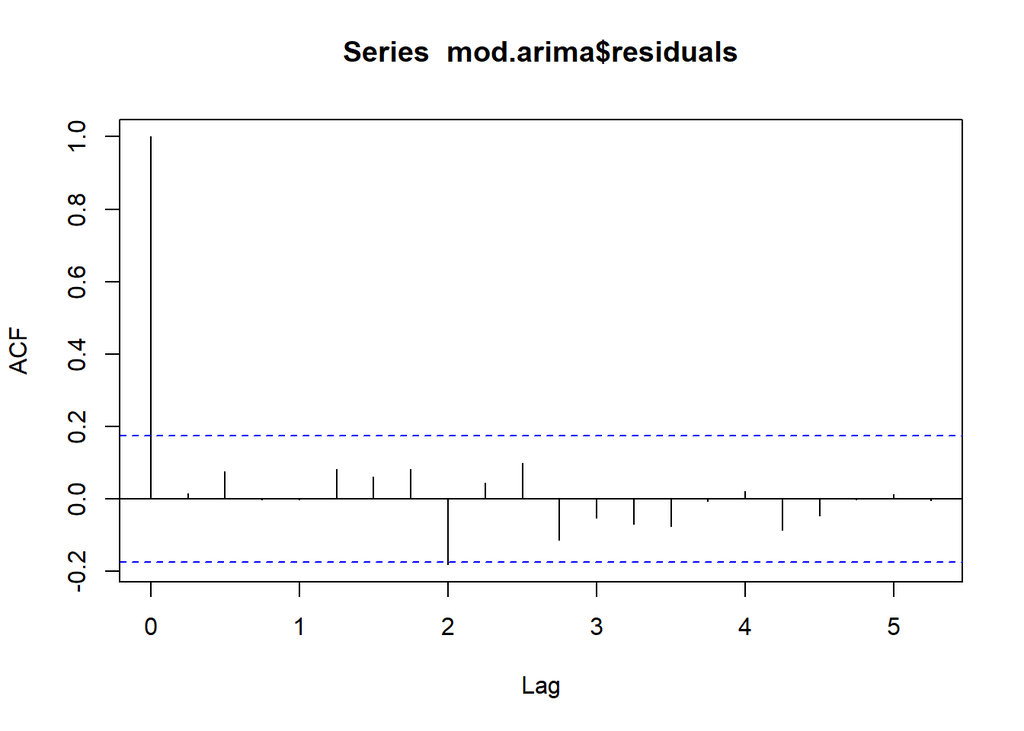

```r
# First fit an ARIMA model on y_t
#mod.arima <- auto.arima(CL_train, max.p = 52, max.q = 52, stationary = TRUE)

# ARIMA(2,0,6) model

mod.arima <- auto.arima(CL_train, max.p = 2, start.p = 2, start.q = 6,
                      max.P = 0, max.Q=0, stationary = TRUE)

acf(mod.arima$residuals)
```

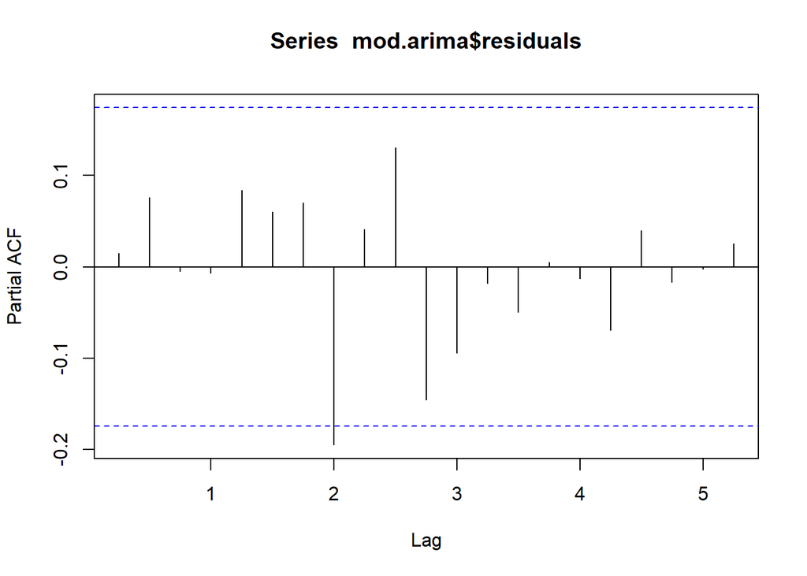

```r
pacf(mod.arima$residuals)
```

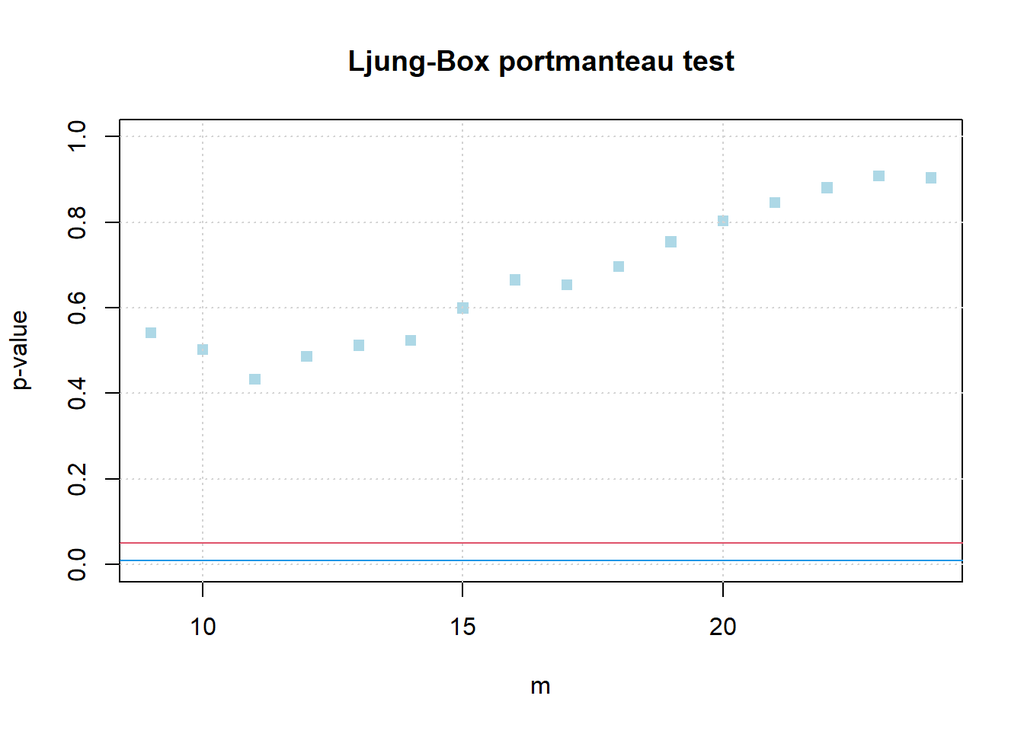

```r
LBTest(mod.arima$residuals, nPQ = 8, ifPlot = TRUE)
```

```r
#' @forecat using auto.arima

yhat_arima <- forecast(mod.arima)
# We only want the first 7 values
yhat_arima <- round(c(as.numeric(yhat_arima$mean)[1:7]), 2)

#' @calculate MSE, MAE, MAPE

MSE_arima <- sqrt(mean((yobs - yhat_arima)^2))
MAE_arima <- mean(abs(yobs - yhat_arima))
MAPE_arima <- mean(abs(1-yhat_arima/yobs))

MSE_arima
```

```
## [1] 0.264791
```

```r
MAE_arima
```

```
## [1] 0.1714286
```

```r
MAPE_arima
```

```
## [1] 0.08009399
```

You can see that the fitted ARIMA(2,0,6) model passes Ljung-Box test.

##### Conduct the same out of sample forecast analysis using forecast combination of the fitted TFN model and ARIMA model (equal weight and MSE weighting). Compare its forecast metrics with those in the previous two questions

- *Forecast combination:*
  The combined forecaster $\hat f_t(i)$ may be given by
  $$\hat f_t(i) = w_a ~ \hat y_t^{(a)}(i)+w_b~ \hat y_t^{(b)}(i),$$
  where the superscripts $(a)$ and $(b)$ stand for transfer function noise model and ARIMA model, respectively. For the equal weight scheme, $w_a = w_b = 0.5$, and for the MSE weighting scheme, its weights is the solution of
  $$\min_{w_a} \sqrt {\sum_{t=1}^n \{y_t -w_a \hat y_t^{(a)}-(1-w_a)\hat y_t^{(b)}\}^2},$$
  where $w_a, w_b \in[0,1]$, $w_a+w_b=1$, and $\hat y_t^{(a)}$ denote the fitted value at time $t$ in the training sample and $n$ is the series length.

```r
#' @calculate MSE, MAE, MAPE for the equal weight forecast

comb_forecast <- 0.5*yhat_tfn + 0.5*yhat_arima

# Forecast Analysis
MSE_equal <- sqrt(mean((yobs - comb_forecast)^2))
MAE_equal <- mean(abs(yobs - comb_forecast))
MAPE_equal <- mean(abs(1-comb_forecast/yobs))

MSE_equal
```

```
## [1] 0.2960031
```

```r
MAE_equal
```

```
## [1] 0.2207143
```

```r
MAPE_equal
```

```
## [1] 0.1015508
```

```r
#' @calculate MSE scheme weight

f <- function(w){
  sum((CL_train - w*(mod.tfn$fitted) - (1-w)*(mod.arima$fitted))^2)
}
# w is our weight for MSE scheme
w <- as.numeric(optimize(f, lower=0, upper=1))[1]


#' @calculate MSE, MAE, MAPE for the above combination forecast

scheme_weight <- w*yhat_tfn + (1-w)*yhat_arima

# Forecast Analysis
MSE_scheme <- sqrt(mean((yobs - scheme_weight)^2))
MAE_scheme <- mean(abs(yobs - scheme_weight))
MAPE_scheme <- mean(abs(1-scheme_weight/yobs))

MSE_scheme
```

```
## [1] 0.3250177
```

```r
MAE_scheme
```

```
## [1] 0.2624169
```

```r
MAPE_scheme
```

```
## [1] 0.1196637
```

Forecast Analysis values for each models shown below:

| Forecast Analysis | TFN | Auto.Arima | Equal Weight | MSE Scheme Weight |  |
| --- | --- | --- | --- | --- | --- |
| MSE | 0.335 | 0.2647 | 0.2960 | 0.3250 |  |
| MAE | 0.2757 | 0.1714 | 0.2207 | 0.2624 |  |
| MAPE | 0.1254 | 0.080 | 0.1015 | 0.1196 |  |

Using the table above, I calculated all the appropriate forecast variance analysis for our models. First, take a look at TFN and auto.ARIMA model. Forecast analysis for TFN model is larger than ARIMA(2,0,6) model. This indicates that ARIMA model actually minimizes variance of the forecast more than the TFN model. Equal weight model seems to have larger forecast analysis than ARIMA values but still less than TFN model. Now if you look at combined forecast, i.e) MSE_Scheme_weight, the optimized weight is 0.87 for TFN model and 0.13 for ARIMA model. Note that equal weight scheme actually has smaller MSE, MAE, MAPE values than optimized weight scheme.

As a bonus, here is the forecast graph using various models we have. You can see that ARIMA model is a lot closer to true values than TFN model.

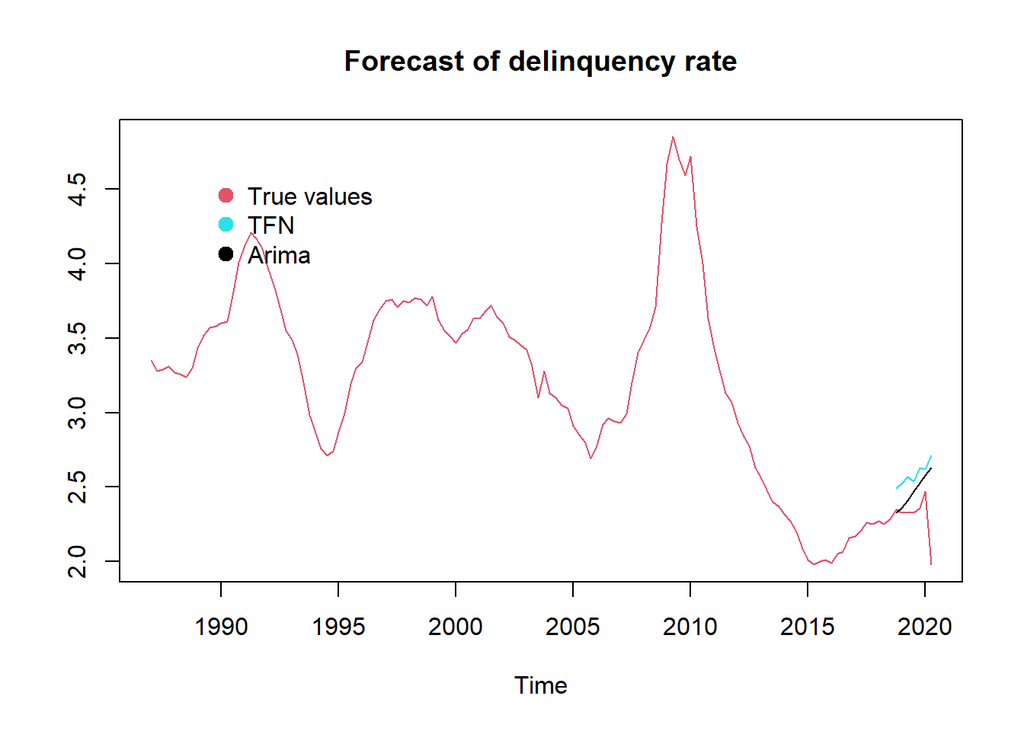

- **Reference:** William W.S. Wei (2006), *Time Series Analysis–Univariate and Multivariate Methods*, Second Edition. (Chapter 14)